# Employee Attrition Analysis and Prediction

Lakshmi Sairam Kakarla

## Inital setup and Loading Dataset

Setting the work environment, Loading the dataset

```r
emp_details<-read.csv("Employee-Attrition.csv")
head(emp_details)
```

|  | Age | Attrition | BusinessTravel | DailyRate | Department | DistanceFromHome | Education | EducationField | EmployeeCount | EmployeeNumber | EnvironmentSatisfaction | Gender | HourlyRate | JobInvolvement | JobLevel | JobRole | JobSatisfaction | MaritalStatus | MonthlyIncome | MonthlyRate | NumCompaniesWorked | Over18 | OverTime | PercentSalaryHike | PerformanceRating | RelationshipSatisfaction | StandardHours | StockOptionLevel | TotalWorkingYears | … |
| --- | --- | --- | --- | --- | --- | --- | --- | --- | --- | --- | --- | --- | --- | --- | --- | --- | --- | --- | --- | --- | --- | --- | --- | --- | --- | --- | --- | --- | --- | --- |
| 1 | 41 | Yes | Travel_Rarely | 1102 | Sales | 1 | 2 | Life Sciences | 1 | 1 | 2 | Female | 94 | 3 | 2 | Sales Executive | 4 | Single | 5993 | 19479 | 8 | Y | Yes | 11 | 3 | 1 | 80 | 0 | 8 | … |
| 2 | 49 | No | Travel_Frequently | 279 | Research & Development | 8 | 1 | Life Sciences | 1 | 2 | 3 | Male | 61 | 2 | 2 | Research Scientist | 2 | Married | 5130 | 24907 | 1 | Y | No | 23 | 4 | 4 | 80 | 1 | 10 | … |
| 3 | 37 | Yes | Travel_Rarely | 1373 | Research & Development | 2 | 2 | Other | 1 | 4 | 4 | Male | 92 | 2 | 1 | Laboratory Technician | 3 | Single | 2090 | 2396 | 6 | Y | Yes | 15 | 3 | 2 | 80 | 0 | 7 | … |
| 4 | 33 | No | Travel_Frequently | 1392 | Research & Development | 3 | 4 | Life Sciences | 1 | 5 | 4 | Female | 56 | 3 | 1 | Research Scientist | 3 | Married | 2909 | 23159 | 1 | Y | Yes | 11 | 3 | 3 | 80 | 0 | 8 | … |
| 5 | 27 | No | Travel_Rarely | 591 | Research & Development | 2 | 1 | Medical | 1 | 7 | 1 | Male | 40 | 3 | 1 | Laboratory Technician | 2 | Married | 3468 | 16632 | 9 | Y | No | 12 | 3 | 4 | 80 | 1 | 6 | … |
| 6 | 32 | No | Travel_Frequently | 1005 | Research & Development | 2 | 2 | Life Sciences | 1 | 8 | 4 | Male | 79 | 3 | 1 | Laboratory Technician | 4 | Single | 3068 | 11864 | 0 | Y | No | 13 | 3 | 3 | 80 | 0 | 8 | … |

## Descriptive Statistics

Finding the number of records in the dataset and the features present.

```r
nrow(emp_details)
```

```
[1] 1470
```

```r
ncol(emp_details)
```

```
[1] 35
```

there are a total of 1470 rows or data points in the dataset. There are total of 35 columns present in the dataset.

Checking for missing values in the data is.na.data.frame returns a matix of Boolean representing the state of missing values column and row wise.

```r
sum(is.na.data.frame(emp_details))
```

```
[1] 0
```

There are no missing values. The dataset was cleaned in prior.

Understanding the various features, datatypes,etc

```r
str(emp_details)
```

```
'data.frame':   1470 obs. of  35 variables:
 $ Age                     : int  41 49 37 33 27 32 59 30 38 36 ...
 $ Attrition               : Factor w/ 2 levels "No","Yes": 2 1 2 1 1 1 1 1 1 1 ...
 $ BusinessTravel          : Factor w/ 3 levels "Non-Travel","Travel_Frequently",..: 3 2 3 2 3 2 3 3 2 3 ...
 $ DailyRate               : int  1102 279 1373 1392 591 1005 1324 1358 216 1299 ...
 $ Department              : Factor w/ 3 levels "Human Resources",..: 3 2 2 2 2 2 2 2 2 2 ...
 $ DistanceFromHome        : int  1 8 2 3 2 2 3 24 23 27 ...
 $ Education               : int  2 1 2 4 1 2 3 1 3 3 ...
 $ EducationField          : Factor w/ 6 levels "Human Resources",..: 2 2 5 2 4 2 4 2 2 4 ...
 $ EmployeeCount           : int  1 1 1 1 1 1 1 1 1 1 ...
 $ EmployeeNumber          : int  1 2 4 5 7 8 10 11 12 13 ...
 $ EnvironmentSatisfaction : int  2 3 4 4 1 4 3 4 4 3 ...
 $ Gender                  : Factor w/ 2 levels "Female","Male": 1 2 2 1 2 2 1 2 2 2 ...
 $ HourlyRate              : int  94 61 92 56 40 79 81 67 44 94 ...
 $ JobInvolvement          : int  3 2 2 3 3 3 4 3 2 3 ...
```

[output cut: 21 more lines]

Detail statistical summary of each variable

```r
summary(emp_details)
```

```
      Age        Attrition            BusinessTravel   DailyRate
 Min.   :18.00   No :1233   Non-Travel       : 150   Min.   : 102.0
 1st Qu.:30.00   Yes: 237   Travel_Frequently: 277   1st Qu.: 465.0
 Median :36.00              Travel_Rarely    :1043   Median : 802.0
 Mean   :36.92                                       Mean   : 802.5
 3rd Qu.:43.00                                       3rd Qu.:1157.0
 Max.   :60.00                                       Max.   :1499.0

                  Department  DistanceFromHome   Education
 Human Resources       : 63   Min.   : 1.000   Min.   :1.000
 Research & Development:961   1st Qu.: 2.000   1st Qu.:2.000
 Sales                 :446   Median : 7.000   Median :3.000
                              Mean   : 9.193   Mean   :2.913
                              3rd Qu.:14.000   3rd Qu.:4.000
                              Max.   :29.000   Max.   :5.000

          EducationField EmployeeCount EmployeeNumber
 Human Resources : 27    Min.   :1     Min.   :   1.0
 Life Sciences   :606    1st Qu.:1     1st Qu.: 491.2
 Marketing       :159    Median :1     Median :1020.5
 Medical         :464    Mean   :1     Mean   :1024.9
 Other           : 82    3rd Qu.:1     3rd Qu.:1555.8
 Technical Degree:132    Max.   :1     Max.   :2068.0

 EnvironmentSatisfaction    Gender      HourlyRate     JobInvolvement
 Min.   :1.000           Female:588   Min.   : 30.00   Min.   :1.00
 1st Qu.:2.000           Male  :882   1st Qu.: 48.00   1st Qu.:2.00
 Median :3.000                        Median : 66.00   Median :3.00
 Mean   :2.722                        Mean   : 65.89   Mean   :2.73
 3rd Qu.:4.000                        3rd Qu.: 83.75   3rd Qu.:3.00
 Max.   :4.000                        Max.   :100.00   Max.   :4.00

    JobLevel                          JobRole    JobSatisfaction
 Min.   :1.000   Sales Executive          :326   Min.   :1.000
 1st Qu.:1.000   Research Scientist       :292   1st Qu.:2.000
 Median :2.000   Laboratory Technician    :259   Median :3.000
 Mean   :2.064   Manufacturing Director   :145   Mean   :2.729
 3rd Qu.:3.000   Healthcare Representative:131   3rd Qu.:4.000
 Max.   :5.000   Manager                  :102   Max.   :4.000
                 (Other)                  :215
```

[output cut: 32 more lines]

```
 YearsAtCompany   YearsInCurrentRole YearsSinceLastPromotion
 Min.   : 0.000   Min.   : 0.000     Min.   : 0.000
 1st Qu.: 3.000   1st Qu.: 2.000     1st Qu.: 0.000
 Median : 5.000   Median : 3.000     Median : 1.000
 Mean   : 7.008   Mean   : 4.229     Mean   : 2.188
 3rd Qu.: 9.000   3rd Qu.: 7.000     3rd Qu.: 3.000
 Max.   :40.000   Max.   :18.000     Max.   :15.000

 YearsWithCurrManager
 Min.   : 0.000
 1st Qu.: 2.000
 Median : 3.000
 Mean   : 4.123
 3rd Qu.: 7.000
 Max.   :17.000
```

The number of attritions are 237 out of 1470 so the majority class prediction would give us an accuracy of

```r
1233/1470
```

```
[1] 0.8387755
```

The majority class prediction is to predict the majority class irrespective of the data. In this data set, the bottom-line for any model we design and implement must be a accuracy of 84%. If models under performs this threshold, there is no reason in implementing the computation intensive models.

## Exploratory Data Analysis

loading “dplyr” data manipulation library

```r
library(dplyr)
is_relatable<-function(c){
  return (is.numeric(c) && sd(c)!=0)
}
```

Applying the above function to draw the correlation matrix

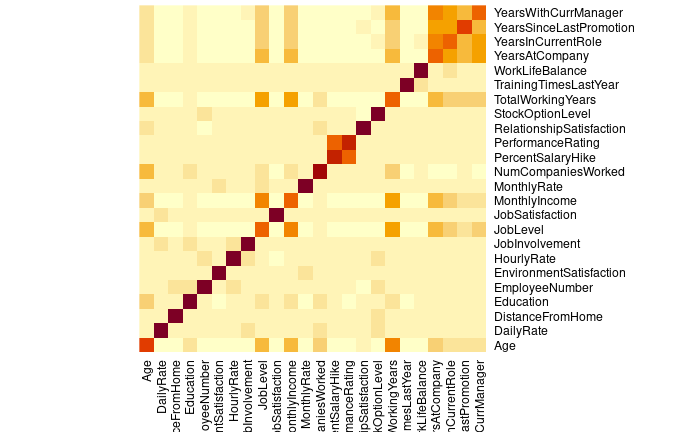

```r
heatmap(cor(select_if(emp_details,is_relatable)),Rowv=NA,Colv = NA)
```

As a rule of thumb correlation above 0.9 are interesting and are supportive enough to derive conclusions. The major correlation observed(0.7) was between percentage salary hike and performance rating. This is natural can be explained by the fact that the high performing individuals are paid more.

Eliminating the irrelevant information

```r
for (i in names(emp_details)) {
  if(sd(as.numeric(emp_details[[i]]))==0){
    print(i)
  }
}
```

```
[1] "EmployeeCount"
[1] "Over18"
[1] "StandardHours"
```

The above three columns show no variance. They don’t contribute to either analytics or predictions for the choosen models.

```r
emp_details<-select(emp_details,-c("EmployeeCount","Over18","StandardHours"))
names(emp_details)
```

```
 [1] "Age"                      "Attrition"
 [3] "BusinessTravel"           "DailyRate"
 [5] "Department"               "DistanceFromHome"
 [7] "Education"                "EducationField"
 [9] "EmployeeNumber"           "EnvironmentSatisfaction"
[11] "Gender"                   "HourlyRate"
[13] "JobInvolvement"           "JobLevel"
[15] "JobRole"                  "JobSatisfaction"
[17] "MaritalStatus"            "MonthlyIncome"
[19] "MonthlyRate"              "NumCompaniesWorked"
[21] "OverTime"                 "PercentSalaryHike"
[23] "PerformanceRating"        "RelationshipSatisfaction"
[25] "StockOptionLevel"         "TotalWorkingYears"
[27] "TrainingTimesLastYear"    "WorkLifeBalance"
[29] "YearsAtCompany"           "YearsInCurrentRole"
[31] "YearsSinceLastPromotion"  "YearsWithCurrManager"
```

Dealing with employee attrition column

```r
str(emp_details$Attrition)
```

```
 Factor w/ 2 levels "No","Yes": 2 1 2 1 1 1 1 1 1 1 ...
```

```r
emp_details$Attrition<-as.numeric((as.numeric(emp_details$Attrition)-1))
unique(emp_details$Attrition)
```

```
[1] 1 0
```

Finding which overall attrition percentage of the organization

```r
sum(emp_details$Attrition)/length(emp_details$Attrition)
```

```
[1] 0.1612245
```

16% is the employee attrition rate in the organization.

# Data Visualization

Finding the employee attrition department wise

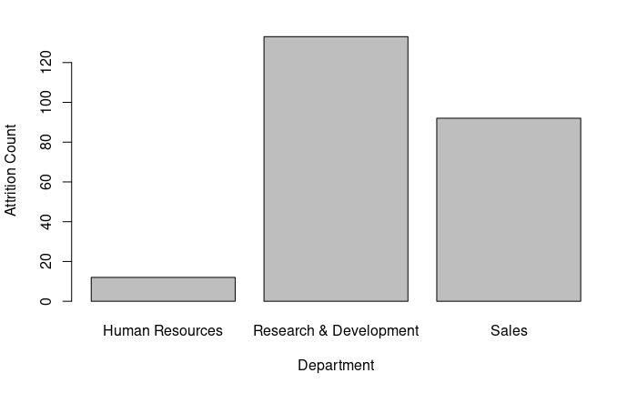

```r
dept_attrition<-aggregate(emp_details$Attrition,by=list(emp_details$Department),FUN=sum)
dept_total<-aggregate(emp_details$Attrition,by=list(emp_details$Department),FUN=length)
barplot(as.numeric(unlist(dept_attrition[2])),names.arg=as.character(unlist(dept_attrition[1])),ylab="Attrition Count",xlab="Department")
```

The employee attrition rates department wise

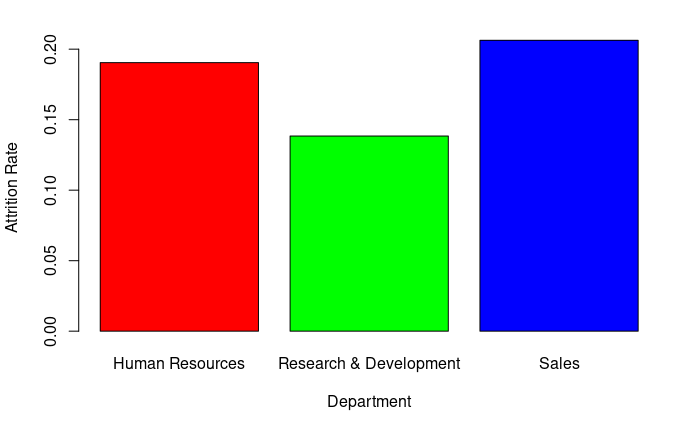

```r
barplot(as.numeric(unlist(dept_attrition[2]/dept_total[2])),names.arg=as.character(unlist(dept_attrition[1])),xlab="Department",ylab="Attrition Rate",col=rainbow(3))
```

The sales department is having the highest employee attrition rate, followed by the Human resources. The least attrition rate is in the Research and Development.

Exploring the employee attrition based on the marital status of employee

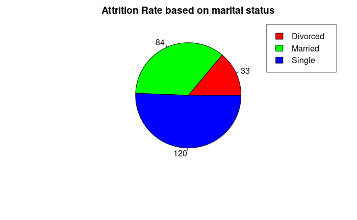

```r
emp_mstatus<-aggregate(emp_details$Attrition,by=list(Status=emp_details$MaritalStatus),FUN=sum)
emp_mTstatus<-aggregate(emp_details$Attrition,by=list(Status=emp_details$MaritalStatus),FUN=length)
pie(as.numeric(unlist(emp_mstatus[2])),labels=as.character(unlist(emp_mstatus[2])),col=rainbow(3),main = "Attrition Rate based on marital status")
legend("topright",as.character(unlist(emp_mstatus[1])),fill=rainbow(3))
```

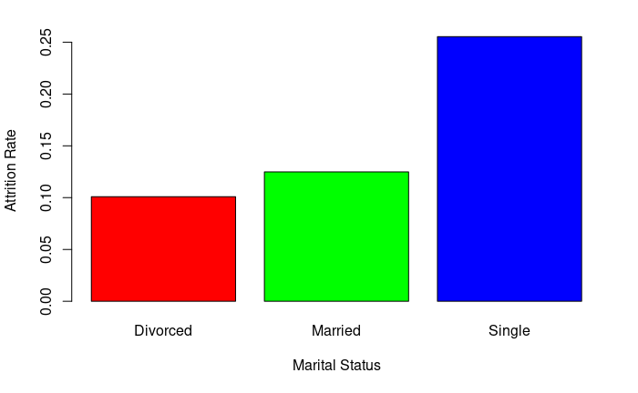

```r
barplot(as.numeric(unlist(emp_mstatus[2]))/as.numeric((unlist(emp_mTstatus[2]))),names.arg=as.character(unlist(emp_mstatus[1])),col=rainbow(3),xlab="Marital Status",ylab="Attrition Rate")
```

Effect of Distance from Home on Employee Attrition

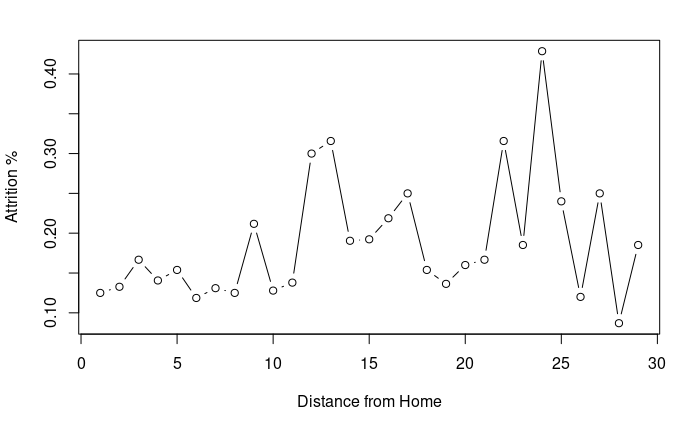

```r
emp_homedist<-aggregate(emp_details$Attrition,by=list(Distance=emp_details$DistanceFromHome),FUN=sum)
emp_homedistT<-aggregate(emp_details$Attrition,by=list(Distance=emp_details$DistanceFromHome),FUN=length)
dist_value<-as.numeric(unlist(emp_homedist[2]))/as.numeric(unlist(emp_homedistT[2]))
plot(x=as.numeric(unlist(emp_homedistT[1])),y=dist_value,type="b",xlab="Distance from Home",ylab="Attrition %")
```

A non-uniform increase in the attrition % can be observed with the increasing distance from home of employee. Its a natural event. But the relative impact of distance from home factor on employee attrition is yet to be explored.

Effect of Work Life Balance on Employee Attrition

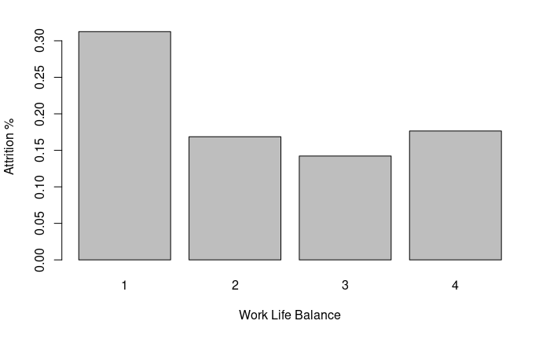

```r
emp_wl<-aggregate(emp_details$Attrition,by=list(WLB=emp_details$WorkLifeBalance),FUN=sum)
emp_wlT<-aggregate(emp_details$Attrition,by=list(WLB=emp_details$WorkLifeBalance),FUN=length)
barplot(as.numeric(unlist(emp_wl[2])/unlist(emp_wlT[2])),names.arg = as.character(unlist(emp_wl[1])),xlab="Work Life Balance",ylab="Attrition %")
```

From the work life balance distribution, it is understood that people with very low work life balance are likely to leave the organization than people with moderate or good work life balance. 30% of employees with 1 work life balance are estimated to leave the company.

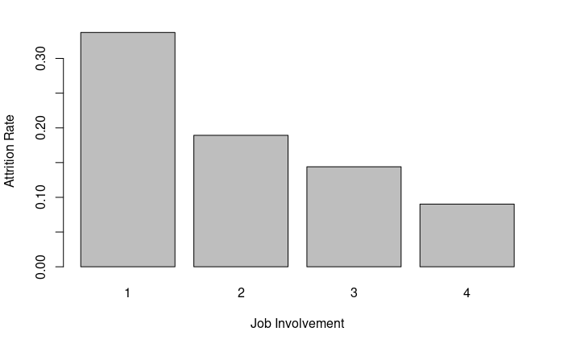

```r
emp_ji<-aggregate(emp_details$Attrition,by=list(JI=emp_details$JobInvolvement),FUN=sum)
emp_jiT<-aggregate(emp_details$Attrition,by=list(JL=emp_details$JobInvolvement),FUN=length)
barplot(as.numeric(unlist(emp_ji[2])/unlist(emp_jiT[2])),names.arg = as.character(unlist(emp_ji[1])),xlab="Job Involvement",ylab="Attrition Rate")
```

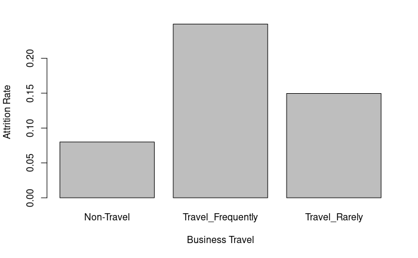

```r
emp_bt<-aggregate(emp_details$Attrition,by=list(BT=emp_details$BusinessTravel),FUN=sum)
emp_btT<-aggregate(emp_details$Attrition,by=list(JL=emp_details$BusinessTravel),FUN=length)
barplot(as.numeric(unlist(emp_bt[2])/unlist(emp_btT[2])),names.arg = as.character(unlist(emp_bt[1])),xlab="Business Travel",ylab="Attrition Rate")
```

JobRole wise Attrition

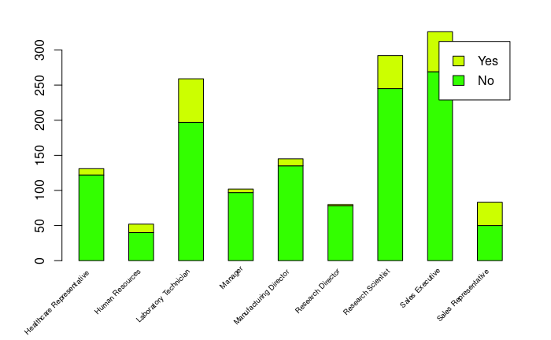

```r
s<-table(select(emp_details,Attrition,JobRole))
plt<-barplot(s,col=c("#33FF00","#CCFF00"),legend.text = c("No","Yes"),xaxt="n",space=1)
text(plt, par("usr")[3], labels = colnames(s), srt = 45, adj = c(1.1,1.1), xpd = TRUE, cex=0.6)
```

### Box-Wisker Plots of numerical data

For Age

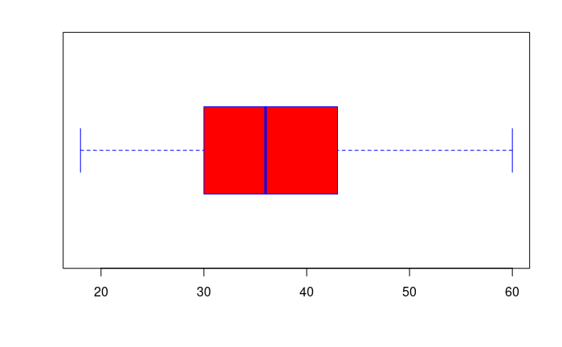

```r
boxplot(emp_details$Age,range=1.5,col=c("red"),border=c("blue"),horizontal = TRUE)
```

For Distance From Home

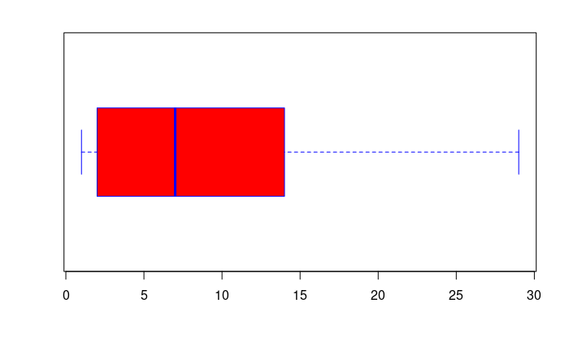

```r
boxplot(emp_details$DistanceFromHome,range=1.5,col=c("red"),border=c("blue"),horizontal = TRUE)
```

For HourlyRate

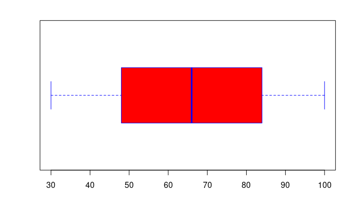

```r
boxplot(emp_details$HourlyRate,range=1.5,col=c("red"),border=c("blue"),horizontal = TRUE)
```

For Monthly Income

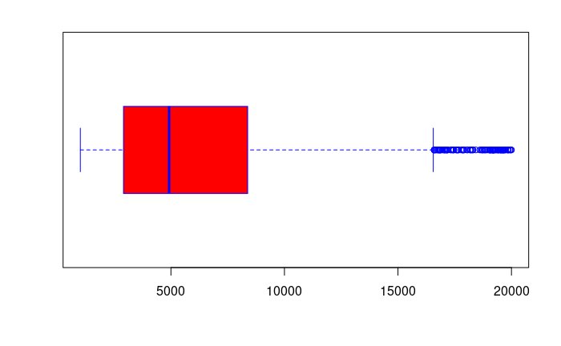

```r
boxplot(emp_details$MonthlyIncome,range=1.5,col=c("red"),border=c("blue"),horizontal = TRUE)
```

Monthly Income has lot a of outliers, need to either apply transformation or eliminate then. Applying Logrithmic Transformation on Monthly Income

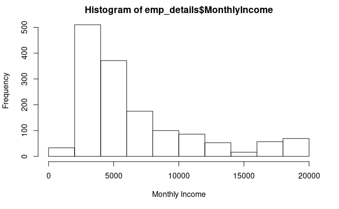

```r
hist(emp_details$MonthlyIncome,xlab="Monthly Income")
```

Histogram after logithmic transformation

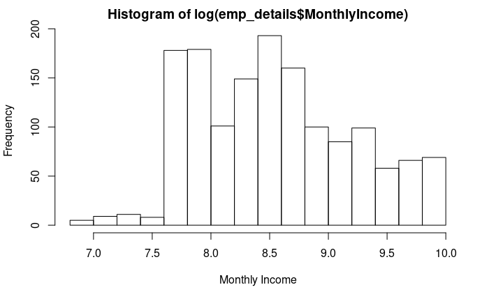

```r
hist(log(emp_details$MonthlyIncome),xlab="Monthly Income")
```

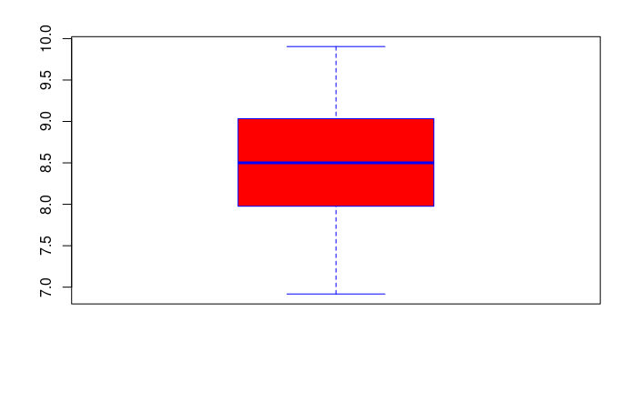

```r
emp_details$MonthlyIncome<-log(emp_details$MonthlyIncome)
boxplot(emp_details$MonthlyIncome,col=c("red"),border=c("blue"),range=1.5)
```

For Monthly Rate

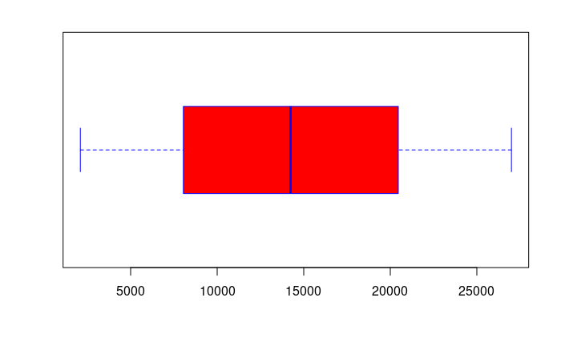

```r
boxplot(emp_details$MonthlyRate,range=1.5,col=c("red"),border=c("blue"),horizontal = TRUE)
```

For Number of Companies Worked

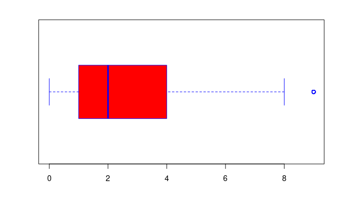

```r
boxplot(emp_details$NumCompaniesWorked,range=1.5,col=c("red"),border=c("blue"),horizontal = TRUE)
```

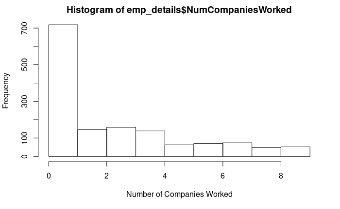

```r
hist(emp_details$NumCompaniesWorked,xlab="Number of Companies Worked")
```

```r
boxplot.stats(emp_details$NumCompaniesWorked)
```

```
$stats
[1] 0 1 2 4 8

$n
[1] 1470

$conf
[1] 1.876371 2.123629

$out
 [1] 9 9 9 9 9 9 9 9 9 9 9 9 9 9 9 9 9 9 9 9 9 9 9 9 9 9 9 9 9 9 9 9 9 9 9 9 9 9 9 9 9 9 9 9 9 9 9 9 9 9 9 9
```

```r
length(emp_details$NumCompaniesWorked[emp_details$NumCompaniesWorked==9])
```

```
[1] 52
```

There are total of 52 employess with Number of Companies Worked as 9.

For Percentage Salary Hike

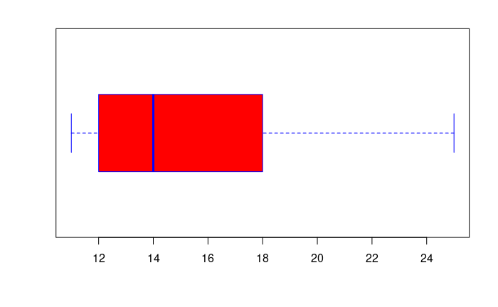

```r
boxplot(emp_details$PercentSalaryHike,range=1.5,col=c("red"),border=c("blue"),horizontal = TRUE)
```

For Total Working Years

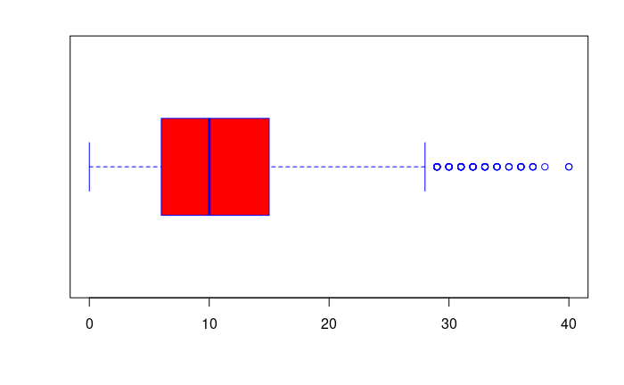

```r
boxplot(emp_details$TotalWorkingYears,range=1.5,col=c("red"),border=c("blue"),horizontal = TRUE)
```

For Years At Company

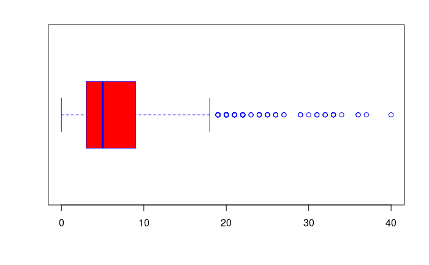

```r
boxplot(emp_details$YearsAtCompany,range=1.5,col=c("red"),border=c("blue"),horizontal = TRUE)
```

For Years in current role

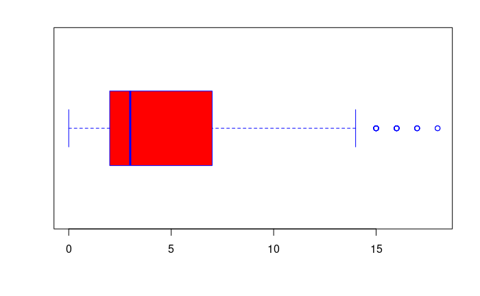

```r
boxplot(emp_details$YearsInCurrentRole,range=1.5,col=c("red"),border=c("blue"),horizontal = TRUE)
```

For Years Since Last Promotion

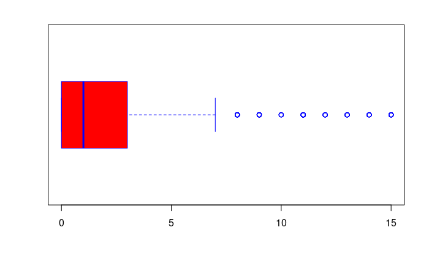

```r
boxplot(emp_details$YearsSinceLastPromotion,range=1.5,col=c("red"),border=c("blue"),horizontal = TRUE)
```

For Years With Current Manager

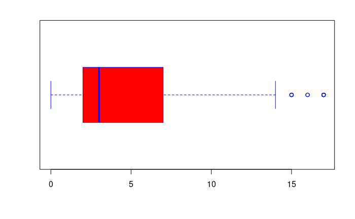

```r
boxplot(emp_details$YearsWithCurrManager,range=1.5,col=c("red"),border=c("blue"),horizontal = TRUE)
```